# Optimal Treatment Analysis

## Outcome Variable

**Outcome Variable:** ever_stunted

## Predictor Variables

**Intervention Variable:** impsan

**Adjustment Set:**

- arm
- sex
- W_mage
- meducyrs
- feducyrs
- hhwealth_quart
- hfoodsec
- W_mhtcm
- W_nrooms
- W_nchldlt5
- W_parity
- impfloor
- safeh20
- delta_W_mage
- delta_meducyrs
- delta_feducyrs
- delta_hhwealth_quart
- delta_hfoodsec
- delta_W_mhtcm
- delta_W_nrooms
- delta_W_nchldlt5
- delta_W_parity
- delta_impfloor
- delta_safeh20

## Stratifying Variables

The analysis was stratified on these variable(s):

- agecat
- studyid
- country

## Data Summary

| agecat | studyid | country | impsan | ever_stunted | n_cell | n |
| --- | --- | --- | --- | --- | --- | --- |
| 0-24 months (no birth st.) | ki0047075b-MAL-ED | BANGLADESH | 0 | 0 | 11 | 203 |
| 0-24 months (no birth st.) | ki0047075b-MAL-ED | BANGLADESH | 0 | 1 | 22 | 203 |
| 0-24 months (no birth st.) | ki0047075b-MAL-ED | BANGLADESH | 1 | 0 | 83 | 203 |
| 0-24 months (no birth st.) | ki0047075b-MAL-ED | BANGLADESH | 1 | 1 | 87 | 203 |
| 0-24 months (no birth st.) | ki0047075b-MAL-ED | BRAZIL | 0 | 0 | 4 | 189 |
| 0-24 months (no birth st.) | ki0047075b-MAL-ED | BRAZIL | 0 | 1 | 0 | 189 |
| 0-24 months (no birth st.) | ki0047075b-MAL-ED | BRAZIL | 1 | 0 | 157 | 189 |
| 0-24 months (no birth st.) | ki0047075b-MAL-ED | BRAZIL | 1 | 1 | 28 | 189 |
| 0-24 months (no birth st.) | ki0047075b-MAL-ED | INDIA | 0 | 0 | 46 | 195 |
| 0-24 months (no birth st.) | ki0047075b-MAL-ED | INDIA | 0 | 1 | 61 | 195 |
| 0-24 months (no birth st.) | ki0047075b-MAL-ED | INDIA | 1 | 0 | 45 | 195 |
| 0-24 months (no birth st.) | ki0047075b-MAL-ED | INDIA | 1 | 1 | 43 | 195 |
| 0-24 months (no birth st.) | ki0047075b-MAL-ED | NEPAL | 0 | 0 | 1 | 209 |
| 0-24 months (no birth st.) | ki0047075b-MAL-ED | NEPAL | 0 | 1 | 0 | 209 |
| 0-24 months (no birth st.) | ki0047075b-MAL-ED | NEPAL | 1 | 0 | 154 | 209 |
| 0-24 months (no birth st.) | ki0047075b-MAL-ED | NEPAL | 1 | 1 | 54 | 209 |
| 0-24 months (no birth st.) | ki0047075b-MAL-ED | PERU | 0 | 0 | 63 | 231 |
| 0-24 months (no birth st.) | ki0047075b-MAL-ED | PERU | 0 | 1 | 111 | 231 |
| 0-24 months (no birth st.) | ki0047075b-MAL-ED | PERU | 1 | 0 | 26 | 231 |
| 0-24 months (no birth st.) | ki0047075b-MAL-ED | PERU | 1 | 1 | 31 | 231 |
| 0-24 months (no birth st.) | ki0047075b-MAL-ED | SOUTH AFRICA | 0 | 0 | 96 | 227 |
| 0-24 months (no birth st.) | ki0047075b-MAL-ED | SOUTH AFRICA | 0 | 1 | 127 | 227 |
| 0-24 months (no birth st.) | ki0047075b-MAL-ED | SOUTH AFRICA | 1 | 0 | 3 | 227 |
| 0-24 months (no birth st.) | ki0047075b-MAL-ED | SOUTH AFRICA | 1 | 1 | 1 | 227 |
| 0-24 months (no birth st.) | ki0047075b-MAL-ED | TANZANIA, UNITED REPUBLIC OF | 0 | 0 | 31 | 202 |
| 0-24 months (no birth st.) | ki0047075b-MAL-ED | TANZANIA, UNITED REPUBLIC OF | 0 | 1 | 171 | 202 |
| 0-24 months (no birth st.) | ki0047075b-MAL-ED | TANZANIA, UNITED REPUBLIC OF | 1 | 0 | 0 | 202 |
| 0-24 months (no birth st.) | ki0047075b-MAL-ED | TANZANIA, UNITED REPUBLIC OF | 1 | 1 | 0 | 202 |
| 0-24 months (no birth st.) | ki1017093-NIH-Birth | BANGLADESH | 0 | 0 | 119 | 530 |
| 0-24 months (no birth st.) | ki1017093-NIH-Birth | BANGLADESH | 0 | 1 | 208 | 530 |

[output cut: 174 more lines]

The following strata were considered:

- agecat: 0-24 months (no birth st.), studyid: ki0047075b-MAL-ED, country: BANGLADESH
- agecat: 0-24 months (no birth st.), studyid: ki0047075b-MAL-ED, country: BRAZIL
- agecat: 0-24 months (no birth st.), studyid: ki0047075b-MAL-ED, country: INDIA
- agecat: 0-24 months (no birth st.), studyid: ki0047075b-MAL-ED, country: NEPAL
- agecat: 0-24 months (no birth st.), studyid: ki0047075b-MAL-ED, country: PERU
- agecat: 0-24 months (no birth st.), studyid: ki0047075b-MAL-ED, country: SOUTH AFRICA
- agecat: 0-24 months (no birth st.), studyid: ki0047075b-MAL-ED, country: TANZANIA, UNITED REPUBLIC OF
- agecat: 0-24 months (no birth st.), studyid: ki1017093-NIH-Birth, country: BANGLADESH
- agecat: 0-24 months (no birth st.), studyid: ki1017093b-PROVIDE, country: BANGLADESH
- agecat: 0-24 months (no birth st.), studyid: ki1017093c-NIH-Crypto, country: BANGLADESH
- agecat: 0-24 months (no birth st.), studyid: ki1114097-CONTENT, country: PERU
- agecat: 0-24 months (no birth st.), studyid: ki1135781-COHORTS, country: GUATEMALA
- agecat: 0-24 months (no birth st.), studyid: ki1135781-COHORTS, country: INDIA
- agecat: 0-24 months (no birth st.), studyid: ki1135781-COHORTS, country: PHILIPPINES
- agecat: 0-24 months (no birth st.), studyid: ki1148112-LCNI-5, country: MALAWI
- agecat: 0-24 months (no birth st.), studyid: kiGH5241-JiVitA-3, country: BANGLADESH
- agecat: 0-24 months (no birth st.), studyid: kiGH5241-JiVitA-4, country: BANGLADESH
- agecat: 0-6 months (no birth st.), studyid: ki0047075b-MAL-ED, country: BANGLADESH
- agecat: 0-6 months (no birth st.), studyid: ki0047075b-MAL-ED, country: BRAZIL
- agecat: 0-6 months (no birth st.), studyid: ki0047075b-MAL-ED, country: INDIA
- agecat: 0-6 months (no birth st.), studyid: ki0047075b-MAL-ED, country: NEPAL
- agecat: 0-6 months (no birth st.), studyid: ki0047075b-MAL-ED, country: PERU
- agecat: 0-6 months (no birth st.), studyid: ki0047075b-MAL-ED, country: SOUTH AFRICA
- agecat: 0-6 months (no birth st.), studyid: ki0047075b-MAL-ED, country: TANZANIA, UNITED REPUBLIC OF
- agecat: 0-6 months (no birth st.), studyid: ki1017093-NIH-Birth, country: BANGLADESH
- agecat: 0-6 months (no birth st.), studyid: ki1017093b-PROVIDE, country: BANGLADESH
- agecat: 0-6 months (no birth st.), studyid: ki1017093c-NIH-Crypto, country: BANGLADESH
- agecat: 0-6 months (no birth st.), studyid: ki1114097-CONTENT, country: PERU
- agecat: 0-6 months (no birth st.), studyid: ki1135781-COHORTS, country: GUATEMALA
- agecat: 0-6 months (no birth st.), studyid: ki1135781-COHORTS, country: INDIA
- agecat: 0-6 months (no birth st.), studyid: ki1135781-COHORTS, country: PHILIPPINES
- agecat: 0-6 months (no birth st.), studyid: ki1148112-LCNI-5, country: MALAWI
- agecat: 0-6 months (no birth st.), studyid: kiGH5241-JiVitA-3, country: BANGLADESH
- agecat: 0-6 months (no birth st.), studyid: kiGH5241-JiVitA-4, country: BANGLADESH
- agecat: 6-24 months, studyid: ki0047075b-MAL-ED, country: BANGLADESH
- agecat: 6-24 months, studyid: ki0047075b-MAL-ED, country: BRAZIL
- agecat: 6-24 months, studyid: ki0047075b-MAL-ED, country: INDIA
- agecat: 6-24 months, studyid: ki0047075b-MAL-ED, country: NEPAL
- agecat: 6-24 months, studyid: ki0047075b-MAL-ED, country: PERU
- agecat: 6-24 months, studyid: ki0047075b-MAL-ED, country: SOUTH AFRICA
- agecat: 6-24 months, studyid: ki0047075b-MAL-ED, country: TANZANIA, UNITED REPUBLIC OF
- agecat: 6-24 months, studyid: ki1017093-NIH-Birth, country: BANGLADESH
- agecat: 6-24 months, studyid: ki1017093b-PROVIDE, country: BANGLADESH
- agecat: 6-24 months, studyid: ki1017093c-NIH-Crypto, country: BANGLADESH
- agecat: 6-24 months, studyid: ki1114097-CONTENT, country: PERU
- agecat: 6-24 months, studyid: ki1135781-COHORTS, country: GUATEMALA
- agecat: 6-24 months, studyid: ki1135781-COHORTS, country: INDIA
- agecat: 6-24 months, studyid: ki1135781-COHORTS, country: PHILIPPINES
- agecat: 6-24 months, studyid: ki1148112-LCNI-5, country: MALAWI
- agecat: 6-24 months, studyid: kiGH5241-JiVitA-3, country: BANGLADESH
- agecat: 6-24 months, studyid: kiGH5241-JiVitA-4, country: BANGLADESH

### Dropped Strata

Some strata were dropped due to rare outcomes:

- agecat: 0-24 months (no birth st.), studyid: ki0047075b-MAL-ED, country: BRAZIL
- agecat: 0-24 months (no birth st.), studyid: ki0047075b-MAL-ED, country: NEPAL
- agecat: 0-24 months (no birth st.), studyid: ki0047075b-MAL-ED, country: SOUTH AFRICA
- agecat: 0-24 months (no birth st.), studyid: ki0047075b-MAL-ED, country: TANZANIA, UNITED REPUBLIC OF
- agecat: 0-24 months (no birth st.), studyid: ki1148112-LCNI-5, country: MALAWI
- agecat: 0-6 months (no birth st.), studyid: ki0047075b-MAL-ED, country: BRAZIL
- agecat: 0-6 months (no birth st.), studyid: ki0047075b-MAL-ED, country: NEPAL
- agecat: 0-6 months (no birth st.), studyid: ki0047075b-MAL-ED, country: SOUTH AFRICA
- agecat: 0-6 months (no birth st.), studyid: ki0047075b-MAL-ED, country: TANZANIA, UNITED REPUBLIC OF
- agecat: 0-6 months (no birth st.), studyid: ki1148112-LCNI-5, country: MALAWI
- agecat: 6-24 months, studyid: ki0047075b-MAL-ED, country: BRAZIL
- agecat: 6-24 months, studyid: ki0047075b-MAL-ED, country: NEPAL
- agecat: 6-24 months, studyid: ki0047075b-MAL-ED, country: SOUTH AFRICA
- agecat: 6-24 months, studyid: ki0047075b-MAL-ED, country: TANZANIA, UNITED REPUBLIC OF
- agecat: 6-24 months, studyid: ki1114097-CONTENT, country: PERU
- agecat: 6-24 months, studyid: ki1148112-LCNI-5, country: MALAWI

## Methods Detail

We’re interested in the causal parameters $E[Y_a]$ for all values of $a \in \mathcal{A}$. These parameters represent the mean outcome if, possibly contrary to fact, we intervened to set all units to have $A=a$. Under the randomization and positivity assumptions, these are identified by the statistical parameters $\psi_a=E_W[E_{Y|A,W}(Y|A=a,W)]$. In addition, we’re interested in the mean of $Y$, $E[Y]$ under no intervention (the observed mean). We will estimate these parameters by using SuperLearner to fit the relevant likelihood factors – $E_{Y|A,W}(Y|A=a,W)$ and $p(A=a|W)$, and then updating our likelihood fit using a joint TMLE.

For unadjusted analyses ($W=\{\}$), initial likelihoods were estimated using Lrnr_glm to estimate the simple $E(Y|A)$ and Lrnr_mean to estimate $p(A)$. For adjusted analyses, a small library containing Lrnr_glmnet, Lrnr_xgboost, and Lrnr_mean was used.

Having estimated these parameters, we will then use the delta method to estimate relative risks and attributable risks relative to a prespecified baseline level of $A$.

# Results Detail

## Results Plots

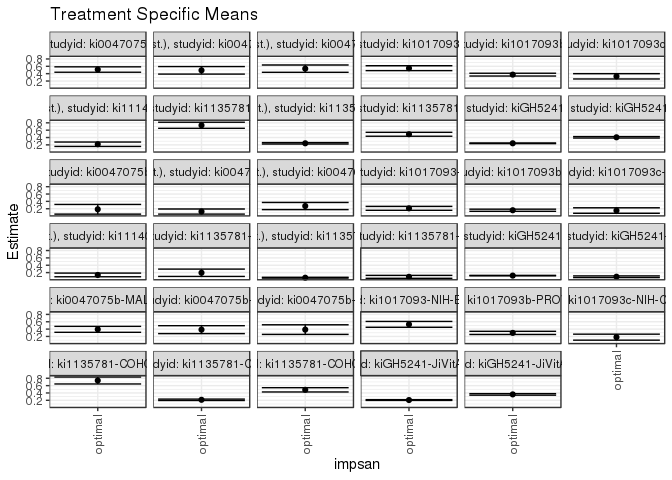

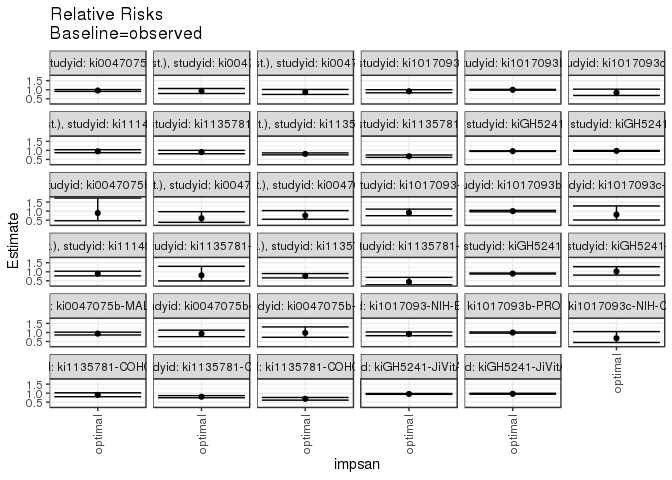

## Results Table

### Parameter: TSM

| agecat | studyid | country | intervention_level | baseline_level | estimate | ci_lower | ci_upper |
| --- | --- | --- | --- | --- | --- | --- | --- |
| 0-24 months (no birth st.) | ki0047075b-MAL-ED | BANGLADESH | optimal | NA | 0.5124042 | 0.4385080 | 0.5863003 |
| 0-24 months (no birth st.) | ki0047075b-MAL-ED | INDIA | optimal | NA | 0.4906987 | 0.3883795 | 0.5930180 |
| 0-24 months (no birth st.) | ki0047075b-MAL-ED | PERU | optimal | NA | 0.5363827 | 0.4372852 | 0.6354801 |
| 0-24 months (no birth st.) | ki1017093-NIH-Birth | BANGLADESH | optimal | NA | 0.5489826 | 0.4821872 | 0.6157779 |
| 0-24 months (no birth st.) | ki1017093b-PROVIDE | BANGLADESH | optimal | NA | 0.3736876 | 0.3351317 | 0.4122436 |
| 0-24 months (no birth st.) | ki1017093c-NIH-Crypto | BANGLADESH | optimal | NA | 0.3275888 | 0.2553752 | 0.3998025 |
| 0-24 months (no birth st.) | ki1114097-CONTENT | PERU | optimal | NA | 0.2174056 | 0.1576556 | 0.2771556 |
| 0-24 months (no birth st.) | ki1135781-COHORTS | GUATEMALA | optimal | NA | 0.7329953 | 0.6504755 | 0.8155151 |
| 0-24 months (no birth st.) | ki1135781-COHORTS | INDIA | optimal | NA | 0.2429501 | 0.2238473 | 0.2620530 |
| 0-24 months (no birth st.) | ki1135781-COHORTS | PHILIPPINES | optimal | NA | 0.4890147 | 0.4355352 | 0.5424942 |
| 0-24 months (no birth st.) | kiGH5241-JiVitA-3 | BANGLADESH | optimal | NA | 0.2431200 | 0.2344828 | 0.2517572 |
| 0-24 months (no birth st.) | kiGH5241-JiVitA-4 | BANGLADESH | optimal | NA | 0.4062091 | 0.3859067 | 0.4265116 |
| 0-6 months (no birth st.) | ki0047075b-MAL-ED | BANGLADESH | optimal | NA | 0.1851513 | 0.0532282 | 0.3170743 |
| 0-6 months (no birth st.) | ki0047075b-MAL-ED | INDIA | optimal | NA | 0.1233960 | 0.0539693 | 0.1928228 |
| 0-6 months (no birth st.) | ki0047075b-MAL-ED | PERU | optimal | NA | 0.2736258 | 0.1767339 | 0.3705178 |
| 0-6 months (no birth st.) | ki1017093-NIH-Birth | BANGLADESH | optimal | NA | 0.2105291 | 0.1576092 | 0.2634489 |
| 0-6 months (no birth st.) | ki1017093b-PROVIDE | BANGLADESH | optimal | NA | 0.1592464 | 0.1300213 | 0.1884715 |
| 0-6 months (no birth st.) | ki1017093c-NIH-Crypto | BANGLADESH | optimal | NA | 0.1509944 | 0.0766580 | 0.2253309 |
| 0-6 months (no birth st.) | ki1114097-CONTENT | PERU | optimal | NA | 0.1359851 | 0.0863493 | 0.1856209 |
| 0-6 months (no birth st.) | ki1135781-COHORTS | GUATEMALA | optimal | NA | 0.1955504 | 0.0957248 | 0.2953761 |
| 0-6 months (no birth st.) | ki1135781-COHORTS | INDIA | optimal | NA | 0.0604114 | 0.0495927 | 0.0712301 |
| 0-6 months (no birth st.) | ki1135781-COHORTS | PHILIPPINES | optimal | NA | 0.0847238 | 0.0447898 | 0.1246577 |
| 0-6 months (no birth st.) | kiGH5241-JiVitA-3 | BANGLADESH | optimal | NA | 0.1185896 | 0.1123742 | 0.1248051 |
| 0-6 months (no birth st.) | kiGH5241-JiVitA-4 | BANGLADESH | optimal | NA | 0.0874967 | 0.0646765 | 0.1103168 |
| 6-24 months | ki0047075b-MAL-ED | BANGLADESH | optimal | NA | 0.3934637 | 0.3127625 | 0.4741649 |
| 6-24 months | ki0047075b-MAL-ED | INDIA | optimal | NA | 0.3851773 | 0.2776273 | 0.4927273 |
| 6-24 months | ki0047075b-MAL-ED | PERU | optimal | NA | 0.3865290 | 0.2561525 | 0.5169054 |
| 6-24 months | ki1017093-NIH-Birth | BANGLADESH | optimal | NA | 0.5292850 | 0.4502325 | 0.6083375 |
| 6-24 months | ki1017093b-PROVIDE | BANGLADESH | optimal | NA | 0.2972077 | 0.2541614 | 0.3402541 |
| 6-24 months | ki1017093c-NIH-Crypto | BANGLADESH | optimal | NA | 0.1806910 | 0.0995463 | 0.2618357 |
| 6-24 months | ki1135781-COHORTS | GUATEMALA | optimal | NA | 0.7390427 | 0.6450751 | 0.8330102 |
| 6-24 months | ki1135781-COHORTS | INDIA | optimal | NA | 0.2139535 | 0.1949749 | 0.2329321 |
| 6-24 months | ki1135781-COHORTS | PHILIPPINES | optimal | NA | 0.4854637 | 0.4276392 | 0.5432882 |
| 6-24 months | kiGH5241-JiVitA-3 | BANGLADESH | optimal | NA | 0.2075154 | 0.1970726 | 0.2179582 |
| 6-24 months | kiGH5241-JiVitA-4 | BANGLADESH | optimal | NA | 0.3609520 | 0.3402553 | 0.3816488 |

### Parameter: E(Y)

| agecat | studyid | country | intervention_level | baseline_level | estimate | ci_lower | ci_upper |
| --- | --- | --- | --- | --- | --- | --- | --- |
| 0-24 months (no birth st.) | ki0047075b-MAL-ED | BANGLADESH | observed | NA | 0.5375127 | 0.4687499 | 0.6062755 |
| 0-24 months (no birth st.) | ki0047075b-MAL-ED | INDIA | observed | NA | 0.5342805 | 0.4640785 | 0.6044826 |
| 0-24 months (no birth st.) | ki0047075b-MAL-ED | PERU | observed | NA | 0.6199551 | 0.5570608 | 0.6828494 |
| 0-24 months (no birth st.) | ki1017093-NIH-Birth | BANGLADESH | observed | NA | 0.6026763 | 0.5609624 | 0.6443902 |
| 0-24 months (no birth st.) | ki1017093b-PROVIDE | BANGLADESH | observed | NA | 0.3754012 | 0.3376275 | 0.4131749 |
| 0-24 months (no birth st.) | ki1017093c-NIH-Crypto | BANGLADESH | observed | NA | 0.3914477 | 0.3536854 | 0.4292099 |
| 0-24 months (no birth st.) | ki1114097-CONTENT | PERU | observed | NA | 0.2283312 | 0.1695576 | 0.2871047 |
| 0-24 months (no birth st.) | ki1135781-COHORTS | GUATEMALA | observed | NA | 0.8116023 | 0.7811287 | 0.8420759 |
| 0-24 months (no birth st.) | ki1135781-COHORTS | INDIA | observed | NA | 0.3012872 | 0.2881884 | 0.3143860 |
| 0-24 months (no birth st.) | ki1135781-COHORTS | PHILIPPINES | observed | NA | 0.7232054 | 0.6969223 | 0.7494886 |
| 0-24 months (no birth st.) | kiGH5241-JiVitA-3 | BANGLADESH | observed | NA | 0.2538448 | 0.2460458 | 0.2616438 |
| 0-24 months (no birth st.) | kiGH5241-JiVitA-4 | BANGLADESH | observed | NA | 0.4178479 | 0.3995429 | 0.4361528 |
| 0-6 months (no birth st.) | ki0047075b-MAL-ED | BANGLADESH | observed | NA | 0.2072637 | 0.1514020 | 0.2631254 |
| 0-6 months (no birth st.) | ki0047075b-MAL-ED | INDIA | observed | NA | 0.2046284 | 0.1478074 | 0.2614493 |
| 0-6 months (no birth st.) | ki0047075b-MAL-ED | PERU | observed | NA | 0.3647355 | 0.3025669 | 0.4269040 |
| 0-6 months (no birth st.) | ki1017093-NIH-Birth | BANGLADESH | observed | NA | 0.2316682 | 0.1958998 | 0.2674365 |
| 0-6 months (no birth st.) | ki1017093b-PROVIDE | BANGLADESH | observed | NA | 0.1596535 | 0.1310628 | 0.1882442 |
| 0-6 months (no birth st.) | ki1017093c-NIH-Crypto | BANGLADESH | observed | NA | 0.1874897 | 0.1573519 | 0.2176275 |
| 0-6 months (no birth st.) | ki1114097-CONTENT | PERU | observed | NA | 0.1522753 | 0.1019748 | 0.2025759 |
| 0-6 months (no birth st.) | ki1135781-COHORTS | GUATEMALA | observed | NA | 0.2442825 | 0.2088246 | 0.2797405 |
| 0-6 months (no birth st.) | ki1135781-COHORTS | INDIA | observed | NA | 0.0783769 | 0.0705840 | 0.0861698 |
| 0-6 months (no birth st.) | ki1135781-COHORTS | PHILIPPINES | observed | NA | 0.1929420 | 0.1697749 | 0.2161091 |
| 0-6 months (no birth st.) | kiGH5241-JiVitA-3 | BANGLADESH | observed | NA | 0.1316788 | 0.1260493 | 0.1373083 |
| 0-6 months (no birth st.) | kiGH5241-JiVitA-4 | BANGLADESH | observed | NA | 0.0856196 | 0.0742558 | 0.0969833 |
| 6-24 months | ki0047075b-MAL-ED | BANGLADESH | observed | NA | 0.4205256 | 0.3435321 | 0.4975190 |
| 6-24 months | ki0047075b-MAL-ED | INDIA | observed | NA | 0.4143157 | 0.3365538 | 0.4920776 |
| 6-24 months | ki0047075b-MAL-ED | PERU | observed | NA | 0.3946932 | 0.3154133 | 0.4739732 |
| 6-24 months | ki1017093-NIH-Birth | BANGLADESH | observed | NA | 0.5761065 | 0.5238499 | 0.6283631 |
| 6-24 months | ki1017093b-PROVIDE | BANGLADESH | observed | NA | 0.2989258 | 0.2568169 | 0.3410347 |
| 6-24 months | ki1017093c-NIH-Crypto | BANGLADESH | observed | NA | 0.2647394 | 0.2260636 | 0.3034151 |
| 6-24 months | ki1135781-COHORTS | GUATEMALA | observed | NA | 0.8170485 | 0.7866892 | 0.8474079 |
| 6-24 months | ki1135781-COHORTS | INDIA | observed | NA | 0.2668168 | 0.2533066 | 0.2803270 |
| 6-24 months | ki1135781-COHORTS | PHILIPPINES | observed | NA | 0.7104163 | 0.6795591 | 0.7412735 |
| 6-24 months | kiGH5241-JiVitA-3 | BANGLADESH | observed | NA | 0.2170072 | 0.2076449 | 0.2263694 |
| 6-24 months | kiGH5241-JiVitA-4 | BANGLADESH | observed | NA | 0.3740356 | 0.3553337 | 0.3927375 |

### Parameter: RR

| agecat | studyid | country | intervention_level | baseline_level | estimate | ci_lower | ci_upper |
| --- | --- | --- | --- | --- | --- | --- | --- |
| 0-24 months (no birth st.) | ki0047075b-MAL-ED | BANGLADESH | optimal | observed | 0.9532876 | 0.9042992 | 1.0049297 |
| 0-24 months (no birth st.) | ki0047075b-MAL-ED | INDIA | optimal | observed | 0.9184290 | 0.7900905 | 1.0676142 |
| 0-24 months (no birth st.) | ki0047075b-MAL-ED | PERU | optimal | observed | 0.8651960 | 0.7377307 | 1.0146847 |
| 0-24 months (no birth st.) | ki1017093-NIH-Birth | BANGLADESH | optimal | observed | 0.9109078 | 0.8296559 | 1.0001171 |
| 0-24 months (no birth st.) | ki1017093b-PROVIDE | BANGLADESH | optimal | observed | 0.9954353 | 0.9740146 | 1.0173272 |
| 0-24 months (no birth st.) | ki1017093c-NIH-Crypto | BANGLADESH | optimal | observed | 0.8368650 | 0.6804114 | 1.0292934 |
| 0-24 months (no birth st.) | ki1114097-CONTENT | PERU | optimal | observed | 0.9521504 | 0.8734404 | 1.0379533 |
| 0-24 months (no birth st.) | ki1135781-COHORTS | GUATEMALA | optimal | observed | 0.9031459 | 0.8146204 | 1.0012915 |
| 0-24 months (no birth st.) | ki1135781-COHORTS | INDIA | optimal | observed | 0.8063739 | 0.7547281 | 0.8615539 |
| 0-24 months (no birth st.) | ki1135781-COHORTS | PHILIPPINES | optimal | observed | 0.6761768 | 0.6126507 | 0.7462900 |
| 0-24 months (no birth st.) | kiGH5241-JiVitA-3 | BANGLADESH | optimal | observed | 0.9577505 | 0.9408338 | 0.9749713 |
| 0-24 months (no birth st.) | kiGH5241-JiVitA-4 | BANGLADESH | optimal | observed | 0.9721460 | 0.9507526 | 0.9940207 |
| 0-6 months (no birth st.) | ki0047075b-MAL-ED | BANGLADESH | optimal | observed | 0.8933125 | 0.4626929 | 1.7247015 |
| 0-6 months (no birth st.) | ki0047075b-MAL-ED | INDIA | optimal | observed | 0.6030251 | 0.3767873 | 0.9651048 |
| 0-6 months (no birth st.) | ki0047075b-MAL-ED | PERU | optimal | observed | 0.7502036 | 0.5479679 | 1.0270774 |
| 0-6 months (no birth st.) | ki1017093-NIH-Birth | BANGLADESH | optimal | observed | 0.9087525 | 0.7446502 | 1.1090190 |
| 0-6 months (no birth st.) | ki1017093b-PROVIDE | BANGLADESH | optimal | observed | 0.9974502 | 0.9578136 | 1.0387271 |
| 0-6 months (no birth st.) | ki1017093c-NIH-Crypto | BANGLADESH | optimal | observed | 0.8053478 | 0.5047911 | 1.2848582 |
| 0-6 months (no birth st.) | ki1114097-CONTENT | PERU | optimal | observed | 0.8930210 | 0.7750090 | 1.0290029 |
| 0-6 months (no birth st.) | ki1135781-COHORTS | GUATEMALA | optimal | observed | 0.8005094 | 0.4922111 | 1.3019114 |
| 0-6 months (no birth st.) | ki1135781-COHORTS | INDIA | optimal | observed | 0.7707804 | 0.6594870 | 0.9008555 |
| 0-6 months (no birth st.) | ki1135781-COHORTS | PHILIPPINES | optimal | observed | 0.4391152 | 0.2793031 | 0.6903687 |
| 0-6 months (no birth st.) | kiGH5241-JiVitA-3 | BANGLADESH | optimal | observed | 0.9005978 | 0.8737176 | 0.9283050 |
| 0-6 months (no birth st.) | kiGH5241-JiVitA-4 | BANGLADESH | optimal | observed | 1.0219238 | 0.8143792 | 1.2823613 |
| 6-24 months | ki0047075b-MAL-ED | BANGLADESH | optimal | observed | 0.9356475 | 0.8618942 | 1.0157119 |
| 6-24 months | ki0047075b-MAL-ED | INDIA | optimal | observed | 0.9296710 | 0.7677788 | 1.1256995 |
| 6-24 months | ki0047075b-MAL-ED | PERU | optimal | observed | 0.9793149 | 0.7327784 | 1.3087964 |
| 6-24 months | ki1017093-NIH-Birth | BANGLADESH | optimal | observed | 0.9187277 | 0.8218823 | 1.0269847 |
| 6-24 months | ki1017093b-PROVIDE | BANGLADESH | optimal | observed | 0.9942525 | 0.9628114 | 1.0267204 |
| 6-24 months | ki1017093c-NIH-Crypto | BANGLADESH | optimal | observed | 0.6825241 | 0.4439691 | 1.0492604 |
| 6-24 months | ki1135781-COHORTS | GUATEMALA | optimal | observed | 0.9045272 | 0.8028071 | 1.0191358 |
| 6-24 months | ki1135781-COHORTS | INDIA | optimal | observed | 0.8018741 | 0.7443649 | 0.8638265 |
| 6-24 months | ki1135781-COHORTS | PHILIPPINES | optimal | observed | 0.6833510 | 0.6138389 | 0.7607348 |
| 6-24 months | kiGH5241-JiVitA-3 | BANGLADESH | optimal | observed | 0.9562608 | 0.9318505 | 0.9813105 |
| 6-24 months | kiGH5241-JiVitA-4 | BANGLADESH | optimal | observed | 0.9650205 | 0.9398203 | 0.9908965 |